# Poc Cover Data with Biogeochem Params and Recruit Counts

Hannah Merges

2024-08-24

### Load libraries

```r
library(tidyverse)
library(here)
library(ggrepel)
library(patchwork)
library(tidytext)
library(AICcmodavg)
library(kableExtra)
library(PNWColors)
library(factoextra)
library(devtools)
library(ggbiplot)
library(car)
```

### Load Data

```r
EnvData_wrecruitcounts <- read_csv(here::here("Data", "CommComp_recruit_seasonavg_envdata.csv"))

Poc_cover_data <- read_csv(here::here("Data", "Species_Composition_2022_Danielle.csv"))

PercentCover <- read_csv("https://raw.githubusercontent.com/dbarnas/Community_Functional_Diversity/main/Data/Full_Metadata.csv")

PercentCover3 <- read_csv(here::here("Data", "PercentCover3.csv"))

RecruitmentCounts2.1 <- read_csv((here::here("Data", "RecruitmentCounts2.1.csv")))
```

## Tidy data and join in Danielle’s Poc cover data

- 1. filter out the sand and hard substrate categories and
- 2. sum the totals by cowtagid to get percent cover of the biotics
- 3. calcualte percent cover of P. acuta based on total amount of biotics in the area
- Add in 0s for the cowtags that don’t have P acuta counts (confirmed with Danielle, August 2024)

```r
Poc_cover_data2 <- Poc_cover_data %>%
  select(!c("Date", "PhotoNum", "Notes")) %>%
  filter(Taxa!="Bare Rock",Taxa!="Sand",Taxa!="Rubble", Location!="Varari_Maya") %>%
  group_by(CowTagID)

Poc_cover_data3 <- Poc_cover_data2 %>%
  dplyr::summarise(total_count_biotics = sum(SpeciesCounts)) %>%
  filter(CowTagID!="VSEEP") ## missing C14

Poc_cover_data4 <- Poc_cover_data2 %>%
  filter(Taxa=="Pocillopora acuta") %>%
  group_by(CowTagID) %>%
  mutate(SpeciesCounts_Poc = SpeciesCounts) %>%
  dplyr::select(!SpeciesCounts)

### joins correlated biotics counts for that CowTag -- still with missing cowtags without P acuta data
Poc_cover_data5 <- Poc_cover_data4 %>%
  left_join(Poc_cover_data3) %>%
  group_by(CowTagID, Location, SpeciesCounts_Poc,total_count_biotics ) %>%
  dplyr::summarise(percent_cover = (SpeciesCounts_Poc/total_count_biotics)*(100))

##########################################
### join together with recruit count env data df and then make sure to add in the zeros for P acuta cowtags
##########################################
EnvData_wPocCover <- EnvData_wrecruitcounts %>%
  full_join(Poc_cover_data5) %>%
  mutate(percent_cover = ifelse(is.na(percent_cover), 0, percent_cover)) %>% ###  ADD IN ZERO FOR COWTAGS WITHOUT P ACUTA COUNTS
  write_csv(here::here("Data", "EnvData_wPocCover.csv"))

##########################################
## using Poc data WITH hard substrate and sand etc
###########################################
Poc_cover_data_withhardsub <- Poc_cover_data %>%
  select(!c("Date", "PhotoNum", "Notes")) %>%
  filter(Location!="Varari_Maya") %>%
  group_by(CowTagID)
```

## Look at recruit totals by how many P acuta at the CowTagID

- might need to square root the percent cover data bc of the variances (shown in recruits_by_PocCover)
- faceted plot = non-transformed percent cover

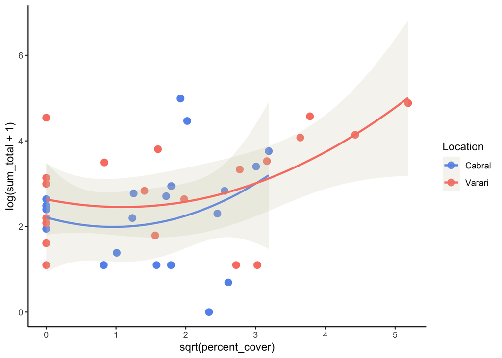

```r
recruits_by_PocCover <- EnvData_wPocCover %>%
  ggplot(aes(x=sqrt(percent_cover),
             y=log(sum_total+1),
             color=Location)) +
  geom_point(size=3) +
  theme_classic() +
  scale_color_manual(values=c("cornflowerblue", "salmon")) +
  geom_smooth(method=lm,
              formula="y~poly(x,2)",
              fill="cornsilk3",
              alpha=0.2) #+ ## alpha adjusts the transparency
 #labs(x="% Cover of P. acuta Species found near tile location",
   #    y="Logged Total of Recruits")

recruits_by_PocCover
```

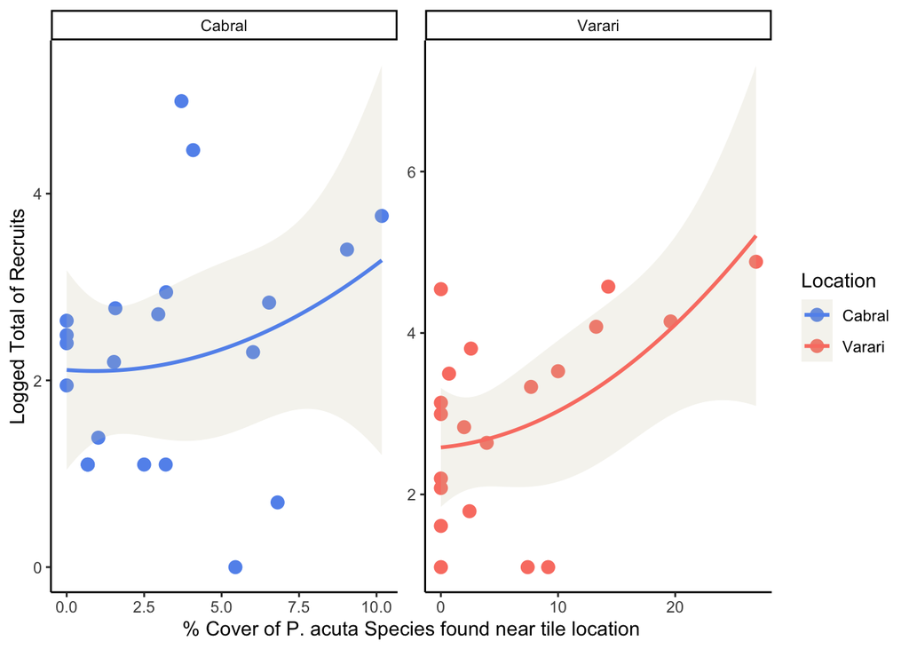

```r
ggsave(here::here("Outputs", "RecruitmentTiles", "recruits_by_PocCover.jpg"))

recruits_by_PocCover_facet <- EnvData_wPocCover %>%
  ggplot(aes(x=percent_cover,
             y=log(sum_total+1),
             color=Location)) +
  geom_point(size=3) +
  theme_classic() +
  scale_color_manual(values=c("cornflowerblue", "salmon")) +
  geom_smooth(method=lm,
              formula="y~poly(x,2)",
              fill="cornsilk3",
              alpha=0.2) + ## alpha adjusts the transparency
  facet_wrap(~Location, scales="free") +
  labs(x="% Cover of P. acuta Species found near tile location",
       y="Logged Total of Recruits")

recruits_by_PocCover_facet
```

```r
ggsave(here::here("Outputs", "RecruitmentTiles", "Results", "Prelim", "recruits_by_PocCover_facet.jpg"))
```

- run models comparing nonlinear vs linear
- **Results**: in the linear model (whether transformed or not), there is a significant effect of cover on the number of settlers but no difference in the average cover or settlers between locations

```r
nonlinear_PacutaCover <- lm(log(sum_total+1) ~ percent_cover + percent_cover^2 , data = EnvData_wPocCover)

anova(nonlinear_PacutaCover)
```

```
## Analysis of Variance Table
##
## Response: log(sum_total + 1)
##               Df Sum Sq Mean Sq F value   Pr(>F)
## percent_cover  1 11.697 11.6974   8.816 0.005086 **
## Residuals     39 51.747  1.3268
## ---
## Signif. codes:  0 '***' 0.001 '**' 0.01 '*' 0.05 '.' 0.1 ' ' 1
```

```r
summary(nonlinear_PacutaCover)
```

```
##
## Call:
## lm(formula = log(sum_total + 1) ~ percent_cover + percent_cover^2,
##     data = EnvData_wPocCover)
##
## Residuals:
##     Min      1Q  Median      3Q     Max
## -2.6940 -0.6233  0.1986  0.4607  2.4580
##
## Coefficients:
##               Estimate Std. Error t value Pr(>|t|)
## (Intercept)    2.18882    0.23047   9.497 1.08e-11 ***
## percent_cover  0.09278    0.03125   2.969  0.00509 **
## ---
## Signif. codes:  0 '***' 0.001 '**' 0.01 '*' 0.05 '.' 0.1 ' ' 1
##
## Residual standard error: 1.152 on 39 degrees of freedom
## Multiple R-squared:  0.1844, Adjusted R-squared:  0.1635
## F-statistic: 8.816 on 1 and 39 DF,  p-value: 0.005086
```

```r
AIC(nonlinear_PacutaCover)
```

```
## [1] 131.8974
```

```r
#### something is up with polynomial models (not working for the second degree)

### with sqrt transformation
linear_PacutaCover_sqrt <- lm(log(sum_total+1) ~ sqrt(percent_cover)*Location, data = EnvData_wPocCover)

anova(linear_PacutaCover_sqrt)
```

```
## Analysis of Variance Table
##
## Response: log(sum_total + 1)
##                              Df Sum Sq Mean Sq F value  Pr(>F)
## sqrt(percent_cover)           1  7.380  7.3795  5.1796 0.02874 *
## Location                      1  3.258  3.2581  2.2868 0.13897
## sqrt(percent_cover):Location  1  0.091  0.0911  0.0640 0.80175
## Residuals                    37 52.715  1.4247
## ---
## Signif. codes:  0 '***' 0.001 '**' 0.01 '*' 0.05 '.' 0.1 ' ' 1
```

```r
summary(linear_PacutaCover_sqrt)
```

```
##
## Call:
## lm(formula = log(sum_total + 1) ~ sqrt(percent_cover) * Location,
##     data = EnvData_wPocCover)
##
## Residuals:
##     Min      1Q  Median      3Q     Max
## -2.4888 -0.7932  0.1541  0.6956  2.5973
##
## Coefficients:
##                                    Estimate Std. Error t value Pr(>|t|)
## (Intercept)                         1.94345    0.48417   4.014  0.00028 ***
## sqrt(percent_cover)                 0.23368    0.26683   0.876  0.38681
## LocationVarari                      0.44046    0.62487   0.705  0.48529
## sqrt(percent_cover):LocationVarari  0.07886    0.31182   0.253  0.80175
## ---
## Signif. codes:  0 '***' 0.001 '**' 0.01 '*' 0.05 '.' 0.1 ' ' 1
##
## Residual standard error: 1.194 on 37 degrees of freedom
## Multiple R-squared:  0.1691, Adjusted R-squared:  0.1017
## F-statistic:  2.51 on 3 and 37 DF,  p-value: 0.07369
```

```r
AIC(linear_PacutaCover_sqrt)
```

```
## [1] 136.6577
```

```r
### withOUT sqrt transformation
linear_PacutaCover <- lm(log(sum_total+1) ~ percent_cover*Location, data = EnvData_wPocCover)

anova(linear_PacutaCover)
```

```
## Analysis of Variance Table
##
## Response: log(sum_total + 1)
##                        Df Sum Sq Mean Sq F value   Pr(>F)
## percent_cover           1 11.697 11.6974  8.6553 0.005599 **
## Location                1  1.704  1.7040  1.2608 0.268731
## percent_cover:Location  1  0.038  0.0382  0.0283 0.867369
## Residuals              37 50.005  1.3515
## ---
## Signif. codes:  0 '***' 0.001 '**' 0.01 '*' 0.05 '.' 0.1 ' ' 1
```

```r
summary(linear_PacutaCover)
```

```
##
## Call:
## lm(formula = log(sum_total + 1) ~ percent_cover * Location, data = EnvData_wPocCover)
##
## Residuals:
##     Min      1Q  Median      3Q     Max
## -2.5109 -0.8471  0.2163  0.6396  2.6494
##
## Coefficients:
##                              Estimate Std. Error t value Pr(>|t|)
## (Intercept)                   1.97979    0.37881   5.226    7e-06 ***
## percent_cover                 0.09753    0.08545   1.141    0.261
## LocationVarari                0.47674    0.50523   0.944    0.351
## percent_cover:LocationVarari -0.01553    0.09236  -0.168    0.867
## ---
## Signif. codes:  0 '***' 0.001 '**' 0.01 '*' 0.05 '.' 0.1 ' ' 1
##
## Residual standard error: 1.163 on 37 degrees of freedom
## Multiple R-squared:  0.2118, Adjusted R-squared:  0.1479
## F-statistic: 3.315 on 3 and 37 DF,  p-value: 0.03033
```

```r
AIC(linear_PacutaCover)
```

```
## [1] 134.4933
```

### Transform Varari data

- try log, sqrt, cube root, reciprocal, exponential, **arc sine**, z-score, and rank transformations
- Ended up going with:

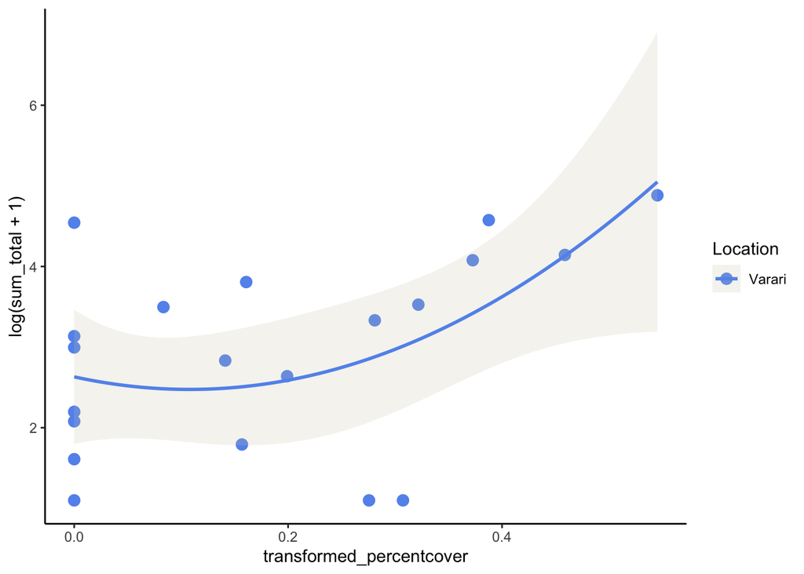

```r
### arc sine transformation
EnvData_wPocCover_Vtransformed <- EnvData_wPocCover %>%
  filter(Location=="Varari") %>%
  mutate(transformed_percentcover = asin(sqrt(percent_cover/100)))

recruits_by_PocCover_facet_transformed_V <- EnvData_wPocCover_Vtransformed %>%
  ggplot(aes(x=transformed_percentcover,
             y=log(sum_total+1),
             color=Location)) +
  geom_point(size=3) +
  theme_classic() +
  scale_color_manual(values=c("cornflowerblue", "salmon")) +
  geom_smooth(method=lm,
              formula="y~poly(x,2)",
              fill="cornsilk3",
              alpha=0.2) #+ ## alpha adjusts the transparency
 # facet_wrap(~Location, scales="free") +
 # labs(x="Transformed % Cover of P. acuta Species found near tile location",
      # y="Logged Total of Recruits")

recruits_by_PocCover_facet_transformed_V
```

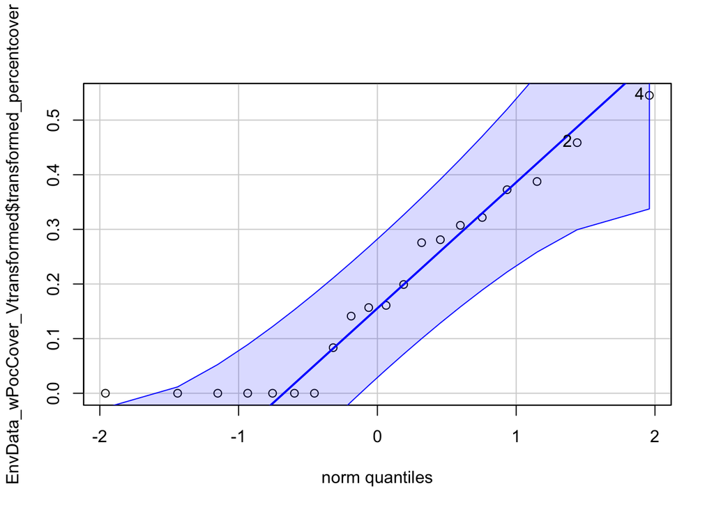

```
## [1] 4 2
```

```r
qqp(EnvData_wPocCover_Vtransformed$transformed_percentcover, "norm")
```

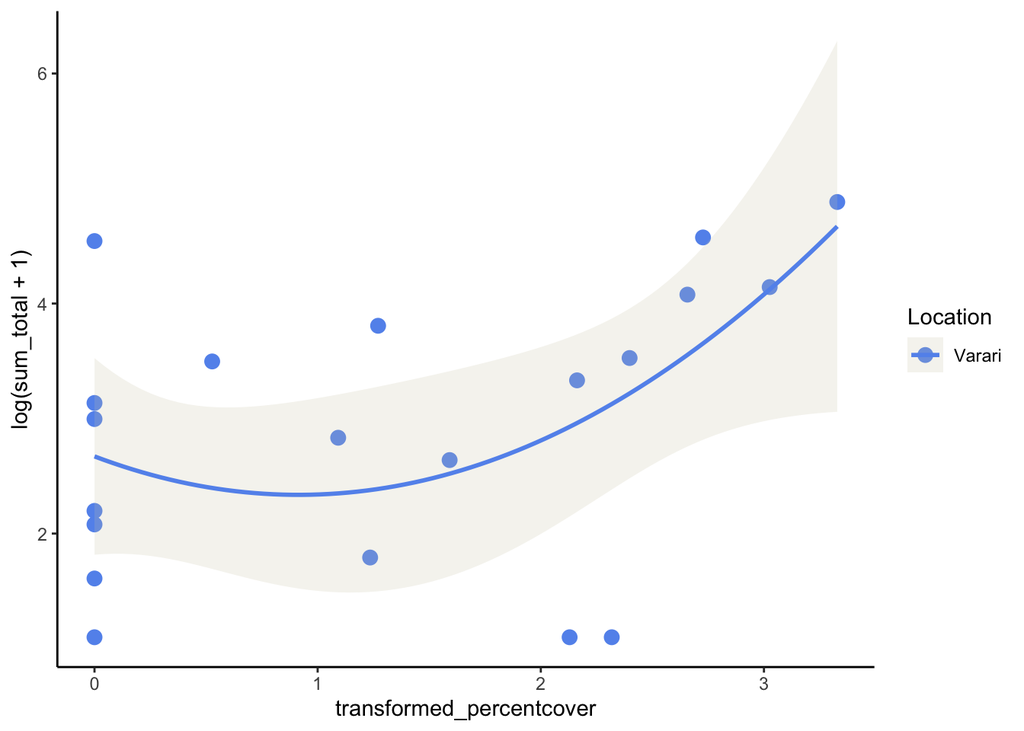

```r
### log transformation
EnvData_wPocCover_Vtransformed2 <- EnvData_wPocCover %>%
  filter(Location=="Varari") %>%
  mutate(transformed_percentcover = log(percent_cover + 1))

recruits_by_PocCover_facet_transformed_V2 <- EnvData_wPocCover_Vtransformed2 %>%
  ggplot(aes(x=transformed_percentcover,
             y=log(sum_total+1),
             color=Location)) +
  geom_point(size=3) +
  theme_classic() +
  scale_color_manual(values=c("cornflowerblue", "salmon")) +
  geom_smooth(method=lm,
              formula="y~poly(x,2)",
              fill="cornsilk3",
              alpha=0.2)

recruits_by_PocCover_facet_transformed_V2
```

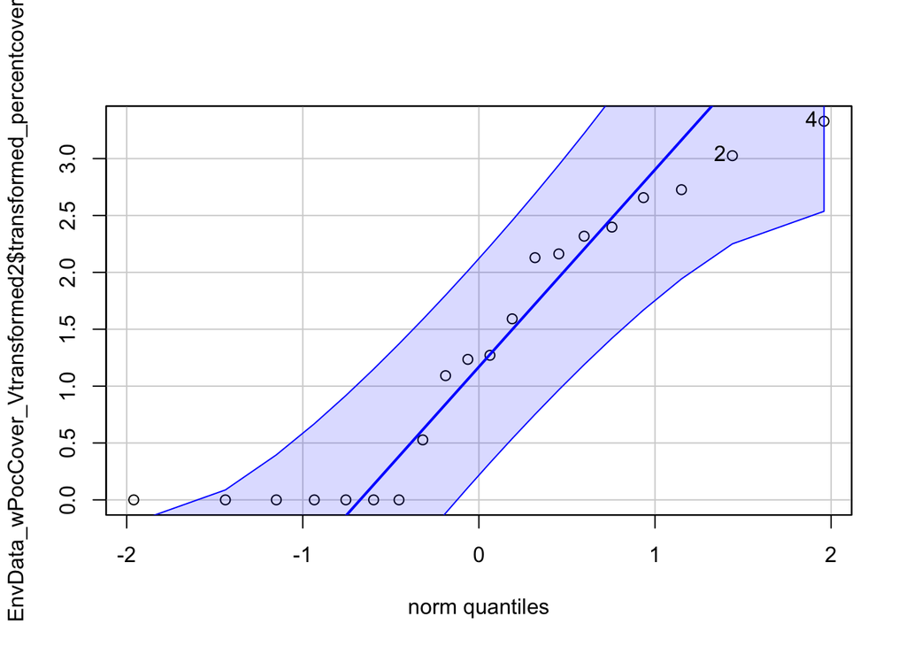

```
## [1] 4 2
```

```r
qqp(EnvData_wPocCover_Vtransformed2$transformed_percentcover, "norm")
```

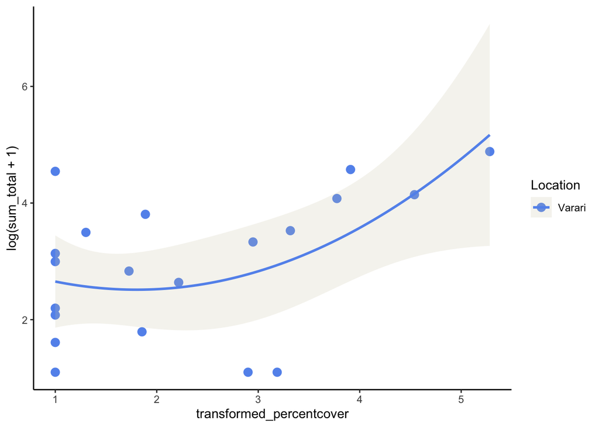

```r
### square root transformation
EnvData_wPocCover_Vtransformed3 <- EnvData_wPocCover %>%
  filter(Location=="Varari") %>%
  mutate(transformed_percentcover = sqrt(percent_cover + 1))

recruits_by_PocCover_facet_transformed_V3 <- EnvData_wPocCover_Vtransformed3 %>%
  ggplot(aes(x=transformed_percentcover,
             y=log(sum_total+1),
             color=Location)) +
  geom_point(size=3) +
  theme_classic() +
  scale_color_manual(values=c("cornflowerblue", "salmon")) +
  geom_smooth(method=lm,
              formula="y~poly(x,2)",
              fill="cornsilk3",
              alpha=0.2)

recruits_by_PocCover_facet_transformed_V3
```

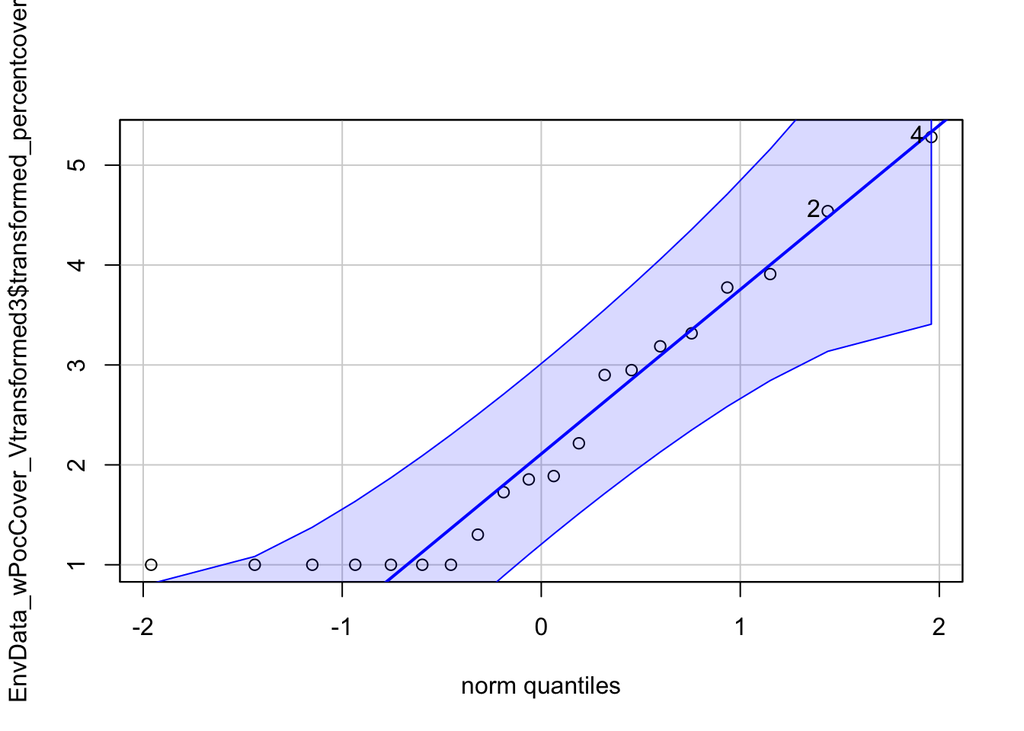

```
## [1] 4 2
```

```r
qqp(EnvData_wPocCover_Vtransformed3$transformed_percentcover, "norm")
```

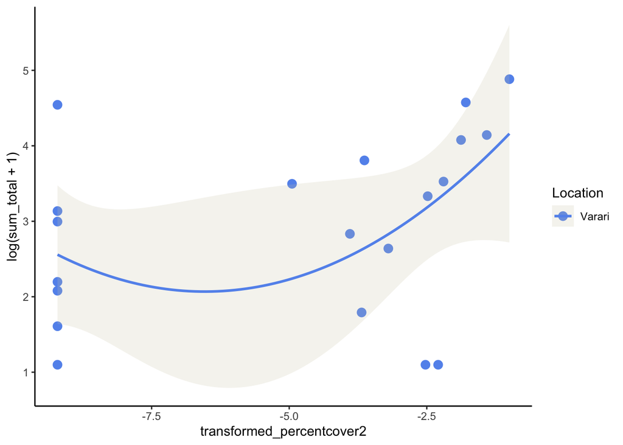

```r
### logit transformation
EnvData_wPocCover_Vtransformed4 <- EnvData_wPocCover %>%
  filter(Location=="Varari") %>%
  mutate(percent_cover_transformed = (percent_cover + 0.01) / 100,
         transformed_percentcover2 = log(percent_cover_transformed / (1 - percent_cover_transformed)))

recruits_by_PocCover_facet_transformed_V4 <- EnvData_wPocCover_Vtransformed4 %>%
  ggplot(aes(x=transformed_percentcover2,
             y=log(sum_total+1),
             color=Location)) +
  geom_point(size=3) +
  theme_classic() +
  scale_color_manual(values=c("cornflowerblue", "salmon")) +
  geom_smooth(method=lm,
              formula="y~poly(x,2)",
              fill="cornsilk3",
              alpha=0.2)

recruits_by_PocCover_facet_transformed_V4
```

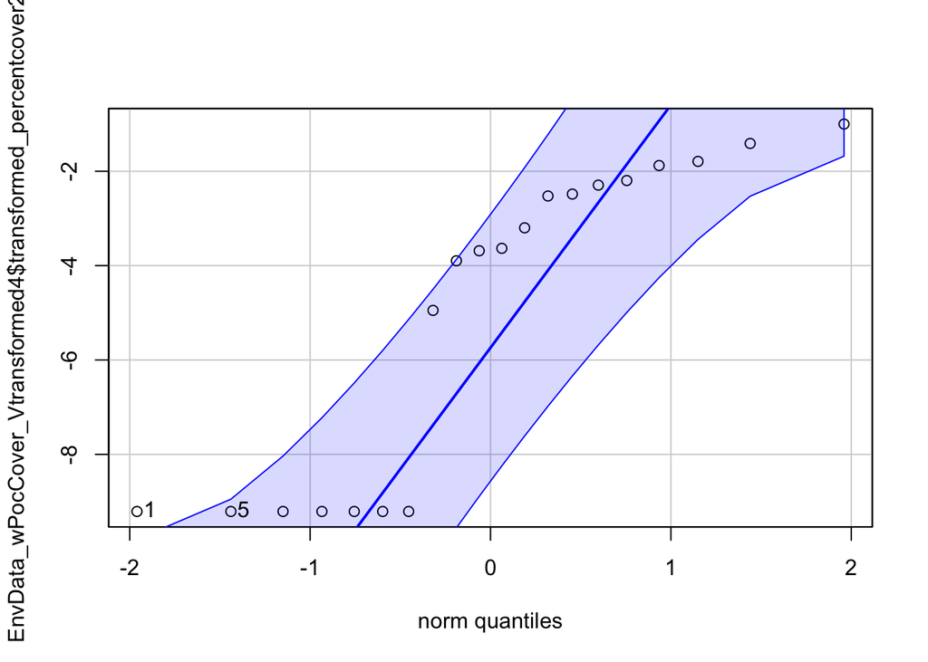

```
## [1] 1 5
```

```r
qqp(EnvData_wPocCover_Vtransformed4$transformed_percentcover2, "norm")
```

ignore below this line ####################################################################################### #######################################################################################

### create a similiar plot for recruits by just hard substrate

Currently getting an error (June 1st, 2024) because don’t have substrate type in the EnvData_wPocCover df anymore Should probably use PercentCover df and group into substrate – might have code somehwere, currently tired

```r
#EnvData_wPocCover_long <- EnvData_wPocCover %>%
#  pivot_longer(cols=Sand:HardSubstrate, names_to = "SubstrateType", values_to = "SubstrateValues")

#recruits_by_HardSubstrate <- EnvData_wPocCover_long %>%
 # ggplot(aes(x=SubstrateValues,
       #      y=log(sum_total+1),
        #     color=SubstrateType)) +
#  geom_point(size=3) +
#  theme_classic() +
#  scale_color_manual(values=c("cornflowerblue", "salmon")) +
 # geom_smooth(method=lm,
           #   fill="cornsilk3",
            #  alpha=0.2) +
 # labs(x="Percent Cover of Hard Substrate vs Sand",
     #  y="Logged Total of Recruits")
#recruits_by_HardSubstrate

#ggsave(here("Outputs", "RecruitmentTiles", "recruits_by_SubstrateType.jpg"))
```

### what about just live coral cover? include Porites, etc

```r
CommComp_recruit_coralcover <- PercentCover3 %>%
  left_join(RecruitmentCounts2.1, join_by(CowTagID, Location))

CommComp_recruit_coralcover_liveonly <- CommComp_recruit_coralcover %>%
  filter(comm_type=="LiveCoral",
         CowTagID!="CSEEP", CowTagID!="VSEEP")

#CommComp_recruit_seasonavg_envdata_wLiveCover <- CommComp_recruit_coralcover_liveonly %>%
 # left_join(AllChemDataSeasonAvg_calculatedvalues, join_by(CowTagID))

#recruits_by_AllLiveCoral <- CommComp_recruit_seasonavg_envdata_wLiveCover %>%
 # ggplot(aes(x=percent_cover,
          #   y=log(sum_total+1),
           #  color=Location)) +
 # geom_point(size=3) +
  #theme_classic() +
#  scale_color_manual(values=c("cornflowerblue", "salmon")) +
#  geom_smooth(method=lm,
         #     fill="cornsilk3",
        #      alpha=0.2) +
 # facet_wrap(~Location) +
 # labs(x="Percent Live Coral",
     #  y= "Log of Total Recruits")
#
#recruits_by_AllLiveCoral

#ggsave(here::here("Outputs", "RecruitmentTiles", "recruits_by_AllLiveCoral.jpg"))
```

### run models comparing total live coral cover vs Poc cover at Varari

- Results: Varari:
- Poc cover: 0.044
- Live coral: 0.0184 Cabral:
- Poc cover: 0.54
- Live coral: 0.44

```r
######################
## all live coral including both sites
######################
#model_livecoral <- lm(log(sum_total+1) ~ percent_cover + Location, data= CommComp_recruit_seasonavg_envdata_wLiveCover)
#summary(model_livecoral)

######################
## just Varari
######################

#CommComp_recruit_coralcover_liveonly_V <- CommComp_recruit_seasonavg_envdata_wLiveCover %>%
 # filter(Location=="Varari")

#model_Vlivecoral <- lm(log(sum_total+1) ~ percent_cover, data= CommComp_recruit_coralcover_liveonly_V)
#summary(model_Vlivecoral)

######################
## just Cabral
######################

#CommComp_recruit_coralcover_liveonly_C <- CommComp_recruit_coralcover_liveonly %>%
 # filter(Location=="Cabral")

#model_Clivecoral <- lm(log(sum_total+1) ~ percent_cover, data= CommComp_recruit_coralcover_liveonly_C)
#summary(model_Clivecoral)

###################################################################
######################
## just Poc cover
######################
#EnvData_wPocCover_V <- EnvData_wPocCover %>%
 # filter(Location=="Varari")

#model_VPocCover <- lm(log(sum_total+1) ~ SpeciesCounts, data= EnvData_wPocCover_V)
#summary(model_VPocCover)


#EnvData_wPocCover_C <- EnvData_wPocCover %>%
 # filter(Location=="Cabral")

#model_CPocCover <- lm(log(sum_total+1) ~ SpeciesCounts, data= EnvData_wPocCover_C)
#summary(model_CPocCover)
```